# Clustering

#### Different density

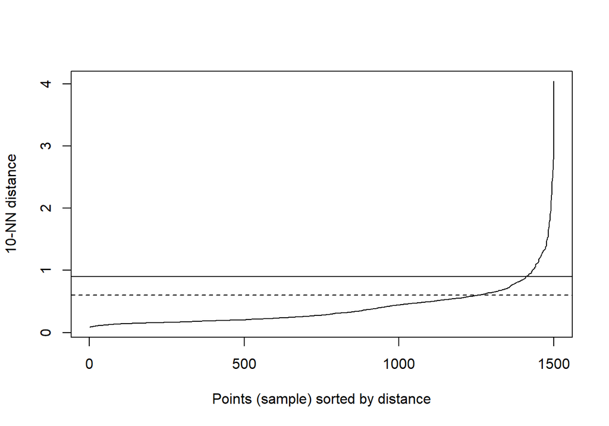

10-nearest neighbour distances for the different density distributions data set

```r
diff_density <- read.csv("data/example_clusters/different_density.csv", header=F)
kNNdistplot(diff_density[,1:2], k=10)
abline(h=0.9)
abline(h=0.6, lty=2)
```

```r
res <- dbscan::dbscan(diff_density[,1:2], eps=0.9, minPts = 10)
table(res$cluster)
```

```
##
##    0    1
##   40 1460
```

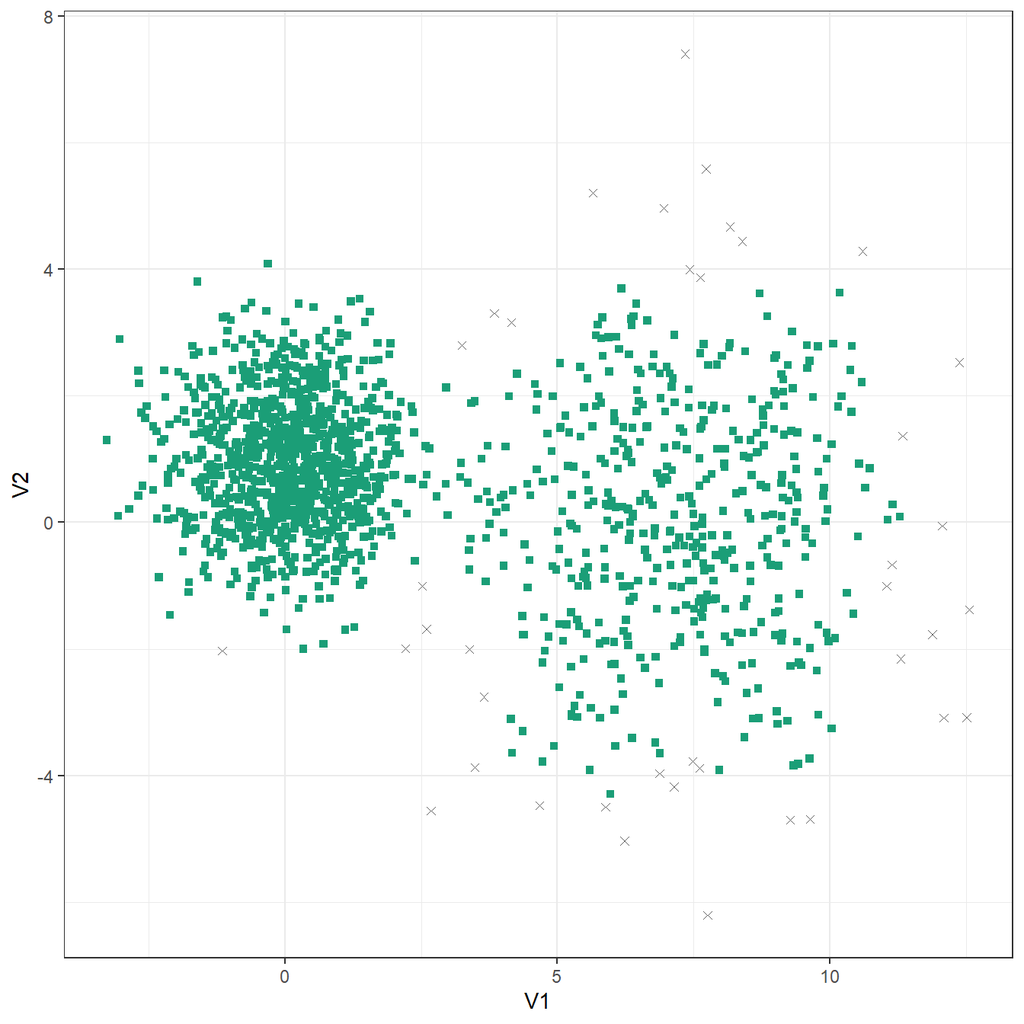

DBSCAN clustering of the different density distribution data set with eps=0.9 and minPts=10. Outlier observations are shown as grey crosses.

```r
plot_dbscan_clusters(diff_density, res)
```

```r
res <- dbscan::dbscan(diff_density[,1:2], eps=0.6, minPts = 10)
table(res$cluster)
```

```
##
##   0   1   2
## 109 399 992
```

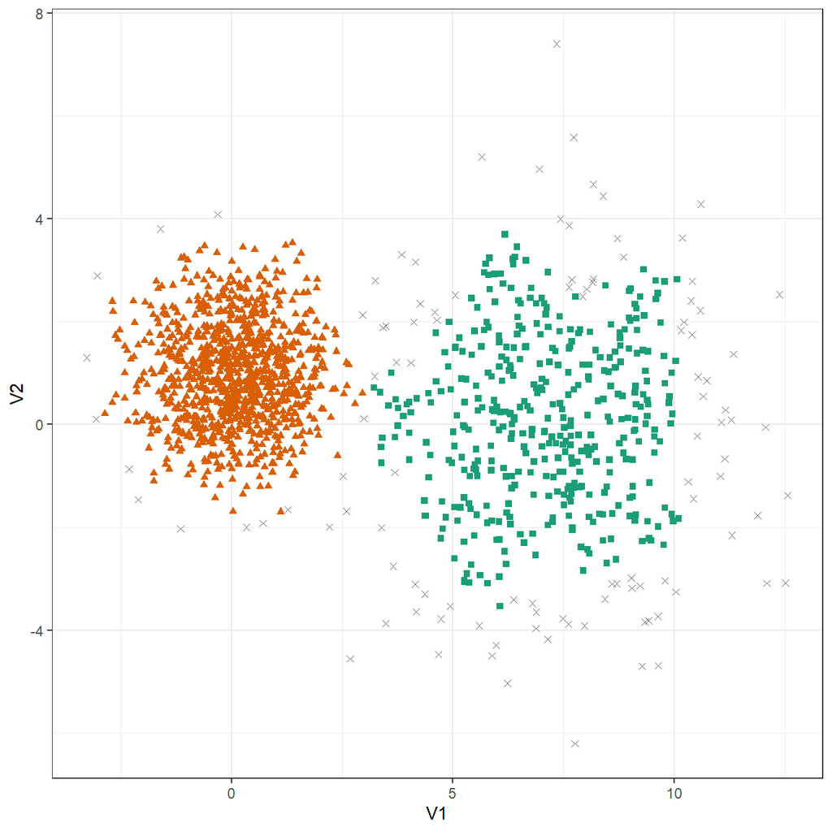

DBSCAN clustering of the different density distribution data set with eps=0.6 and minPts=10. Outlier observations are shown as grey crosses.

```r
plot_dbscan_clusters(diff_density, res)
```

#### Anisotropic distributions

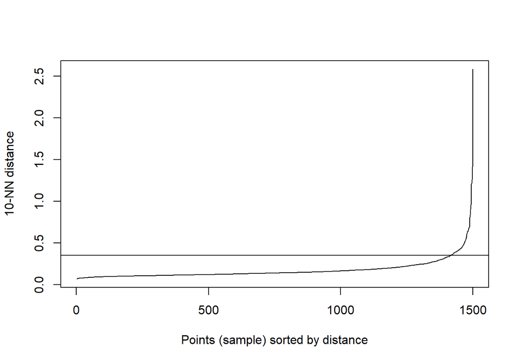

10-nearest neighbour distances for the anisotropic distributions data set

```r
aniso <- read.csv("data/example_clusters/aniso.csv", header=F)
kNNdistplot(aniso[,1:2], k=10)
abline(h=0.35)
```

```r
res <- dbscan::dbscan(aniso[,1:2], eps=0.35, minPts = 10)
table(res$cluster)
```

```
##
##   0   1   2   3
##  29 489 488 494
```

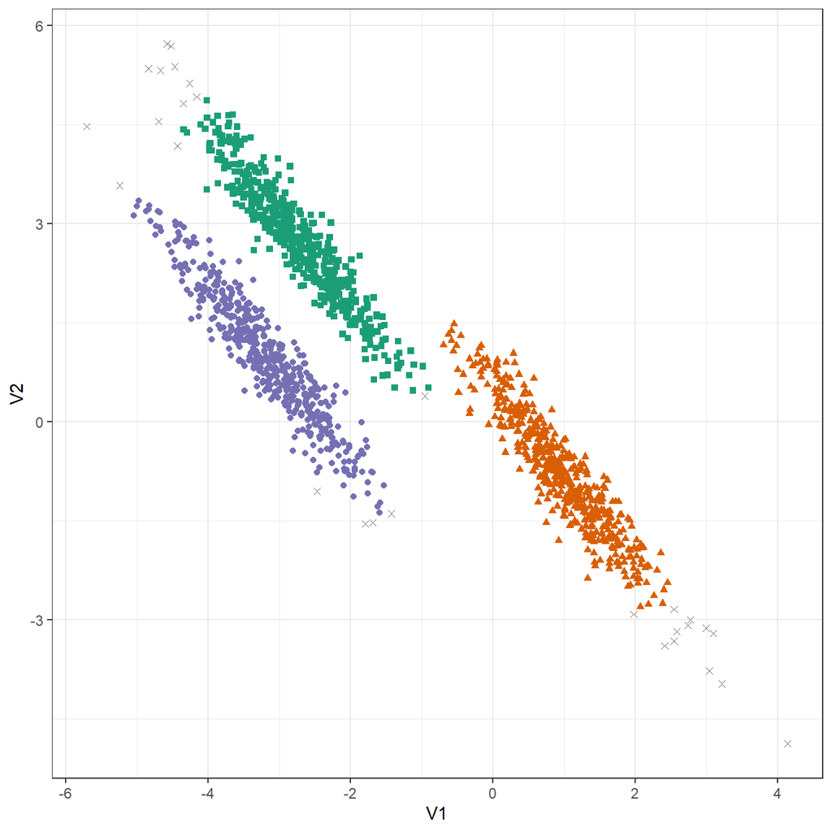

```r
plot_dbscan_clusters(aniso, res)
```

#### No structure

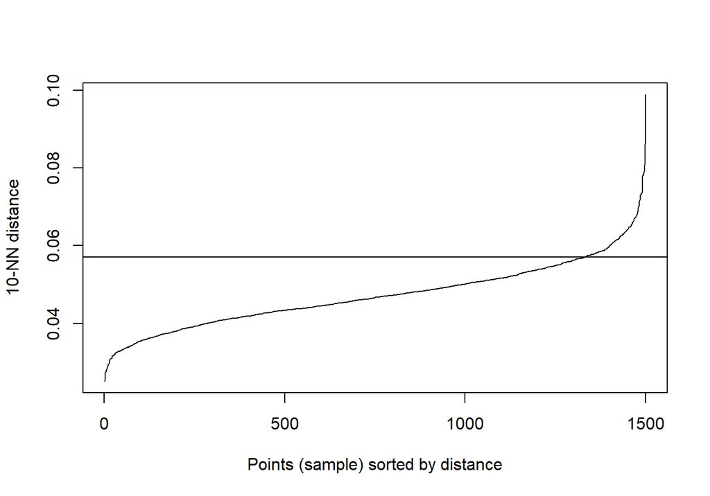

10-nearest neighbour distances for the data set with no structure.

```r
no_structure <- read.csv("data/example_clusters/no_structure.csv", header=F)
kNNdistplot(no_structure[,1:2], k=10)
abline(h=0.057)
```

```r
res <- dbscan::dbscan(no_structure[,1:2], eps=0.57, minPts = 10)
table(res$cluster)
```

```
##
##    1
## 1500
```

## Evaluating cluster quality

### Silhouette method

**Silhouette**
$$\begin{equation}
s(i) = \frac{b(i) - a(i)}{max\left(a(i),b(i)\right)}
(\#eq:silhouette)
\end{equation}$$

Where

- *a(i)* - average dissimmilarity of *i* with all other data within the cluster. *a(i)* can be interpreted as how well *i* is assigned to its cluster (the smaller the value, the better the assignment).
- *b(i)* - the lowest average dissimilarity of *i* to any other cluster, of which *i* is not a member.

Observations with a large *s(i)* (close to 1) are very well clustered. Observations lying between clusters will have a small *s(i)* (close to 0). If an observation has a negative *s(i)*, it has probably been placed in the wrong cluster.

### Example - k-means clustering of blobs data set

Load library required for calculating silhouette coefficients and plotting silhouettes.

```r
library(cluster)
```

We are going to take another look at k-means clustering of the blobs data-set. Specifically we are going to see if silhouette analysis supports our original choice of k=3 as the optimum number of clusters.

Silhouette analysis requires a minimum of two clusters, so we’ll try values of k from 2 to 9.

```r
k <- 2:9
```

Create a palette of colours for plotting.

```r
kColours <- brewer.pal(9,"Set1")
```

Perform k-means clustering for each value of k from 2 to 9.

```r
res <- lapply(k, function(i){kmeans(blobs[,1:2], i, nstart=50)})
```

Calculate the Euclidean distance matrix

```r
d <- dist(blobs[,1:2])
```

Silhouette plot for k=2

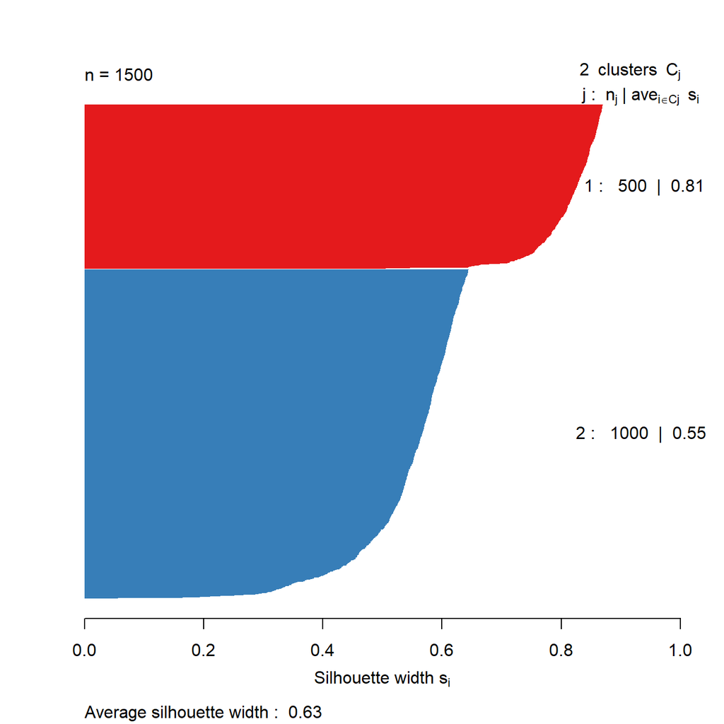

Silhouette plot for k-means clustering of the blobs data set with k=2.

```r
s2 <- silhouette(res[[2-1]]$cluster, d)
plot(s2, border=NA, col=kColours[sort(res[[2-1]]$cluster)], main="")
```

Silhouette plot for k=9

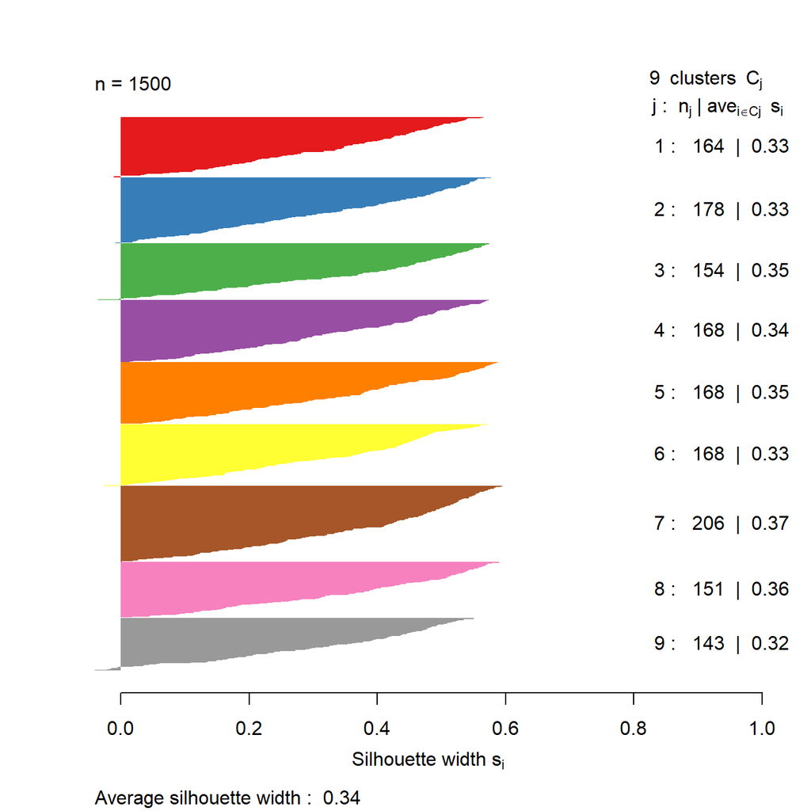

Silhouette plot for k-means clustering of the blobs data set with k=9.

```r
s9 <- silhouette(res[[9-1]]$cluster, d)
plot(s9, border=NA, col=kColours[sort(res[[9-1]]$cluster)], main="")
```

Let’s take a look at the silhouette plot for k=3.

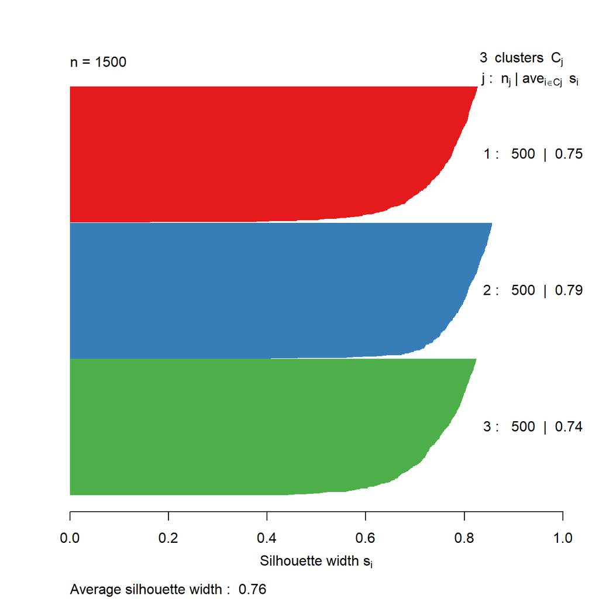

Silhouette plot for k-means clustering of the blobs data set with k=3.

```r
s3 <- silhouette(res[[3-1]]$cluster, d)
plot(s3, border=NA, col=kColours[sort(res[[3-1]]$cluster)], main="")
```

So far the silhouette plots have shown that k=3 appears to be the optimum number of clusters, but we should investigate the silhouette coefficients at other values of k. Rather than produce a silhouette plot for each value of k, we can get a useful summary by making a barplot of average silhouette coefficients.

First we will calculate the silhouette coefficient for every observation (we need to index our list of **kmeans** outputs by `i-1`, because we are counting from k=2 ).

```r
s <- lapply(k, function(i){silhouette(res[[i-1]]$cluster, d)})
```

We can then calculate the mean silhouette coefficient for each value of k from 2 to 9.

```r
avgS <- sapply(s, function(x){mean(x[,3])})
```

Now we have the data we need to produce a barplot.

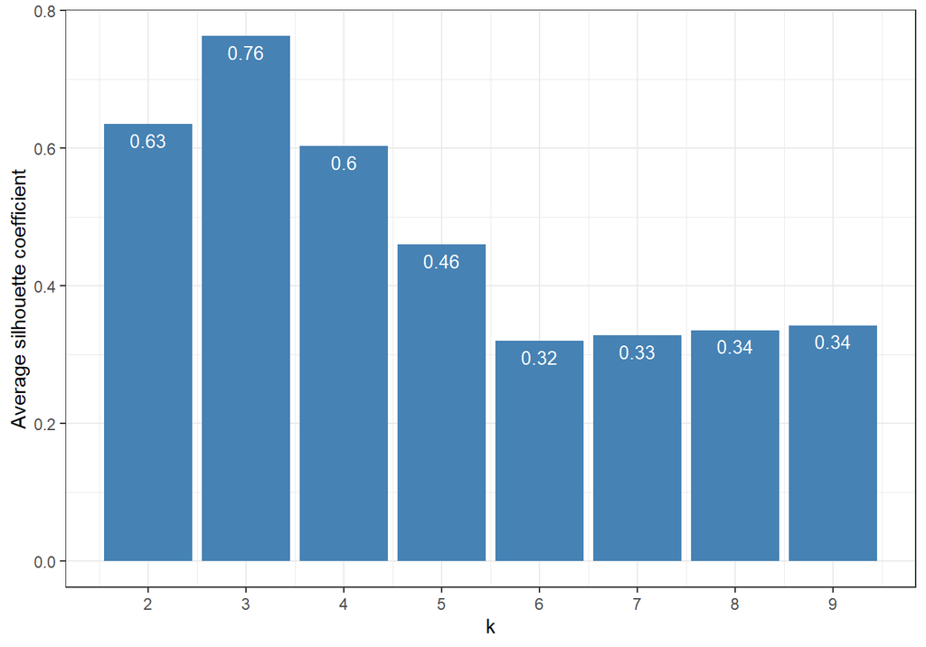

```r
dat <- data.frame(k, avgS)
ggplot(data=dat, aes(x=k, y=avgS)) +
         geom_bar(stat="identity", fill="steelblue") +
  geom_text(aes(label=round(avgS,2)), vjust=1.6, color="white", size=3.5)+
  labs(y="Average silhouette coefficient") +
  scale_x_continuous(breaks=2:9) +
  theme_bw()
```

The bar plot confirms that the optimum number of clusters is three.

### Example - DBSCAN clustering of noisy moons

The clusters that DBSCAN found in the noisy moons data set were presented earlier.

Let’s repeat clustering, because the original result is no longer in memory.

```r
res <- dbscan::dbscan(noisy_moons[,1:2], eps=0.075, minPts = 10)
```

Identify noise points as we do not want to include these in the silhouette analysis

```r
# identify and remove noise points
noise <- res$cluster==0
```

Remove noise points from cluster results

```r
clusters <- res$cluster[!noise]
```

Generate distance matrix from `noisy_moons` data.frame, exluding noise points.

```r
d <- dist(noisy_moons[!noise,1:2])
```

Silhouette analysis

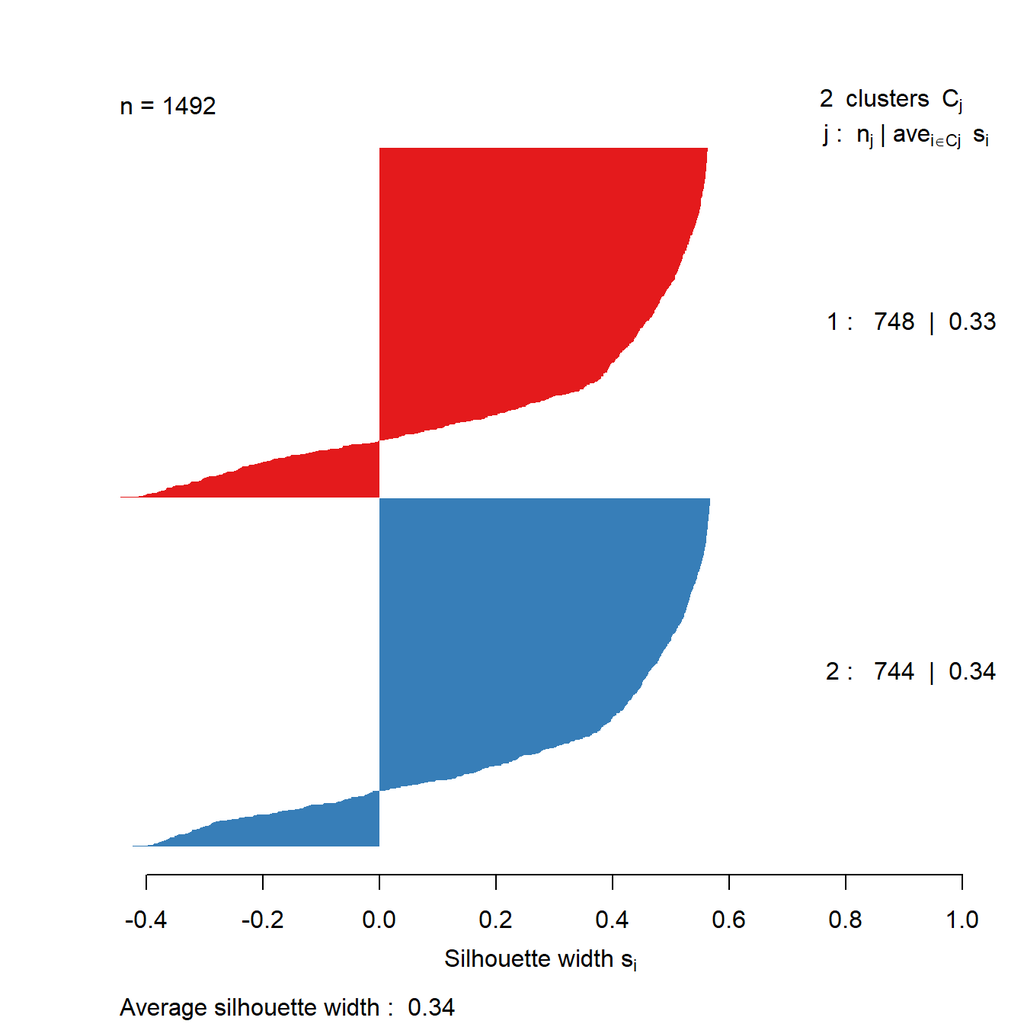

Silhouette plot for DBSCAN clustering of the noisy moons data set.

```r
clusterColours <- brewer.pal(9,"Set1")
sil <- silhouette(clusters, d)
plot(sil, border=NA, col=clusterColours[sort(clusters)], main="")
```

The silhouette analysis suggests that DBSCAN has found clusters of poor quality in the noisy moons data set. However, we saw by eye that it it did a good job of deliminiting the two clusters. The result demonstrates that the silhouette method is less useful when dealing with clusters that are defined by density, rather than inertia.

## Example: gene expression profiling of human tissues

### Hierarchic agglomerative

#### Basics

Load required libraries

```r
library(RColorBrewer)
library(dendextend)
```

Load data

```r
load("data/tissues_gene_expression/tissuesGeneExpression.rda")
```

Inspect data

```r
table(tissue)
```

```
## tissue
##  cerebellum       colon endometrium hippocampus      kidney       liver
##          38          34          15          31          39          26
##    placenta
##           6
```

```r
dim(e)
```

```
## [1] 22215   189
```

Compute distance between each sample

```r
d <- dist(t(e))
```

perform hierarchical clustering

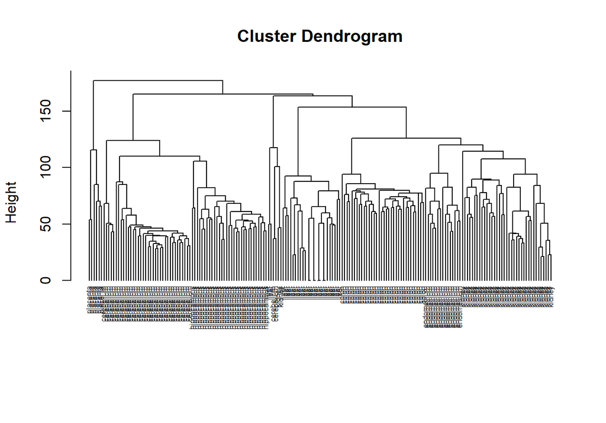

Clustering of tissue samples based on gene expression profiles.

```r
hc <- hclust(d, method="average")
plot(hc, labels=tissue, cex=0.5, hang=-1, xlab="", sub="")
```

#### Colour labels

The dendextend library can be used to plot dendrogram with colour labels

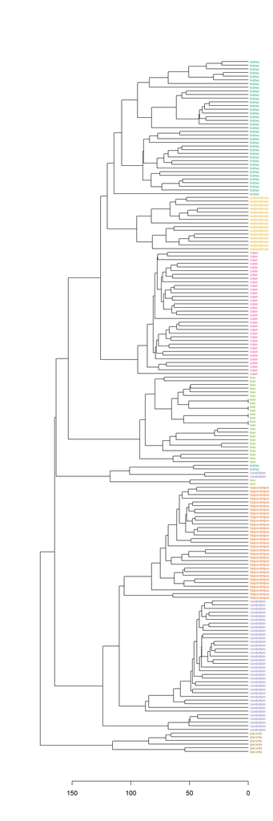

Clustering of tissue samples based on gene expression profiles with labels coloured by tissue type.

```r
tissue_type <- unique(tissue)
dend <- as.dendrogram(hc)
dend_colours <- brewer.pal(length(unique(tissue)),"Dark2")
names(dend_colours) <- tissue_type
labels(dend) <- tissue[order.dendrogram(dend)]
labels_colors(dend) <- dend_colours[tissue][order.dendrogram(dend)]
labels_cex(dend) = 0.5
plot(dend, horiz=T)
```

#### Defining clusters by cutting tree

Define clusters by cutting tree at a specific height

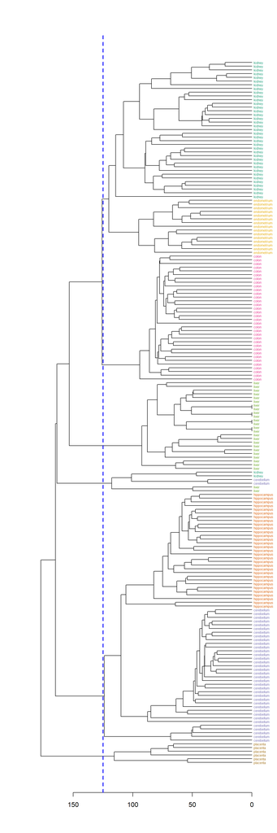

Clusters found by cutting tree at a height of 125

```r
plot(dend, horiz=T)
abline(v=125, lwd=2, lty=2, col="blue")
```

```r
hclusters <- cutree(dend, h=125)
table(tissue, cluster=hclusters)
```

```
##              cluster
## tissue         1  2  3  4  5  6
##   cerebellum   0 36  0  0  2  0
##   colon        0  0 34  0  0  0
##   endometrium 15  0  0  0  0  0
##   hippocampus  0 31  0  0  0  0
##   kidney      37  0  0  0  2  0
##   liver        0  0  0 24  2  0
##   placenta     0  0  0  0  0  6
```

Select a specific number of clusters.

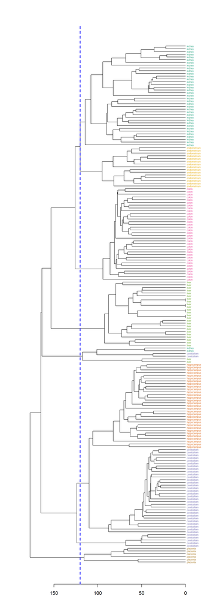

Selection of eight clusters from the dendogram

```r
plot(dend, horiz=T)
abline(v = heights_per_k.dendrogram(dend)["8"], lwd = 2, lty = 2, col = "blue")
```

```r
hclusters <- cutree(dend, k=8)
table(tissue, cluster=hclusters)
```

```
##              cluster
## tissue         1  2  3  4  5  6  7  8
##   cerebellum   0 31  0  0  2  0  5  0
##   colon        0  0 34  0  0  0  0  0
##   endometrium  0  0  0  0  0 15  0  0
##   hippocampus  0 31  0  0  0  0  0  0
##   kidney      37  0  0  0  2  0  0  0
##   liver        0  0  0 24  2  0  0  0
##   placenta     0  0  0  0  0  0  0  6
```

#### Heatmap

Base R provides a **heatmap** function, but we will use the more advanced **heatmap.2** from the **gplots** package.

```r
library(gplots)
```

Define a colour palette (also known as a lookup table).

```r
heatmap_colours <- colorRampPalette(brewer.pal(9, "PuBuGn"))(100)
```

Calculate the variance of each gene.

```r
geneVariance <- apply(e,1,var)
```

Find the row numbers of the 40 genes with the highest variance.

```r
idxTop40 <- order(-geneVariance)[1:40]
```

Define colours for tissues.

```r
tissueColours <- palette(brewer.pal(8, "Dark2"))[as.numeric(as.factor(tissue))]
```

Plot heatmap.

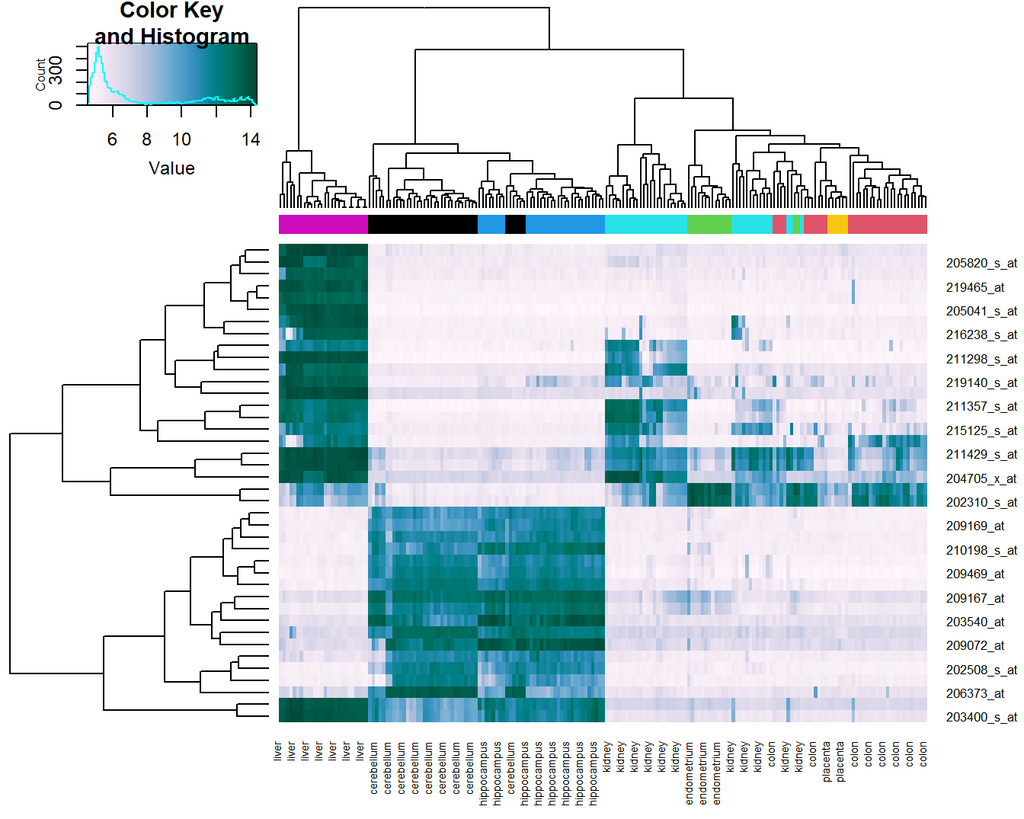

Heatmap of the expression of the 40 genes with the highest variance.

```r
heatmap.2(e[idxTop40,], labCol=tissue, trace="none",
          ColSideColors=tissueColours, col=heatmap_colours)
```

### K-means

Load data if not already in workspace.

```r
load("data/tissues_gene_expression/tissuesGeneExpression.rda")
```

As we saw earlier, the data set contains expression levels for over 22,000 transcripts in seven tissues.

```r
table(tissue)
```

```
## tissue
##  cerebellum       colon endometrium hippocampus      kidney       liver
##          38          34          15          31          39          26
##    placenta
##           6
```

```r
dim(e)
```

```
## [1] 22215   189
```

First we will examine the total intra-cluster variance with different values of *k*. Our data-set is fairly large, so clustering it for several values or *k* and with multiple random starting centres is computationally quite intensive. Fortunately the task readily lends itself to parallelization; we can assign the analysis of each ‘k’ to a different processing core. As we have seen in the previous chapters on supervised learning, [caret](http://cran.r-project.org/web/packages/caret/index.html) has parallel processing built in and we simply have to load a package for multicore processing, such as [doMC](http://cran.r-project.org/web/packages/doMC/index.html), and then register the number of cores we would like to use. Running **kmeans** in parallel is slightly more involved, but still very easy. We will start by loading [doMC](http://cran.r-project.org/web/packages/doMC/index.html) and registering all available cores:

```r
library(doMC)
registerDoMC(detectCores())
```

To find out how many cores we have registered we can use:

```r
getDoParWorkers()
```

```
## [1] 1
```

Instead of using the **lapply** function to vectorize our code, we will instead use the parallel equivalent, **foreach**. Like **lapply**, **foreach** returns a list by default. For this example we have set a seed, rather than generate a random number, for the sake of reproducibility. Ordinarily we would omit `set.seed(42)` and `.options.multicore=list(set.seed=FALSE)`.

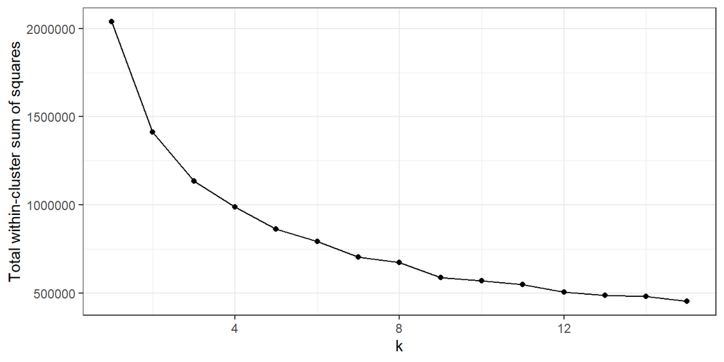

K-means clustering of human tissue gene expression: variance within clusters.

```r
k<-1:15
set.seed(42)
res_k_15 <- foreach(
  i=k,
  .options.multicore=list(set.seed=FALSE)) %dopar% kmeans(t(e), i, nstart=10)
plot_tot_withinss(res_k_15)
```

There is no obvious elbow, but since we know that there are seven tissues in the data set we will try k=7.

```r
table(tissue, res_k_15[[7]]$cluster)
```

```
##
## tissue         1  2  3  4  5  6  7
##   cerebellum   0  0  0  0  5  0 33
##   colon        0  0  0  0  0 34  0
##   endometrium 15  0  0  0  0  0  0
##   hippocampus  0  0  0  0 31  0  0
##   kidney       0  0 39  0  0  0  0
##   liver        0 26  0  0  0  0  0
##   placenta     0  0  0  6  0  0  0
```

The analysis has found a distinct cluster for each tissue and therefore performed slightly better than the earlier hierarchical clustering analysis, which placed endometrium and kidney observations in the same cluster.

To visualize the result in a 2D scatter plot we first need to apply dimensionality reduction. We will use principal component analysis (PCA), which was described in the dimensionality reduction chapter.

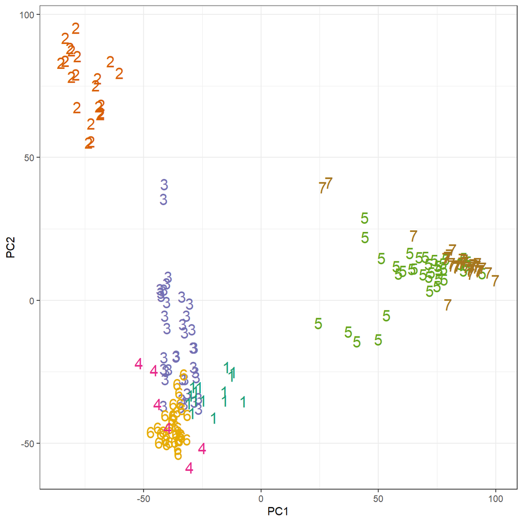

K-means clustering of human gene expression (k=7): scatterplot of first two principal components.

```r
pca <- prcomp(t(e))
ggplot(data=as.data.frame(pca$x), aes(PC1,PC2)) +
  geom_point(col=brewer.pal(7,"Dark2")[res_k_15[[7]]$cluster],
             shape=c(49:55)[res_k_15[[7]]$cluster], size=5) +
  theme_bw()
```

### DBSCAN

Load data if not already in workspace.

```r
load("data/tissues_gene_expression/tissuesGeneExpression.rda")
```

Get a summary of the data set.

```r
table(tissue)
```

```
## tissue
##  cerebellum       colon endometrium hippocampus      kidney       liver
##          38          34          15          31          39          26
##    placenta
##           6
```

We’ll try k=5 (default for dbscan), because there are only six observations for placenta.

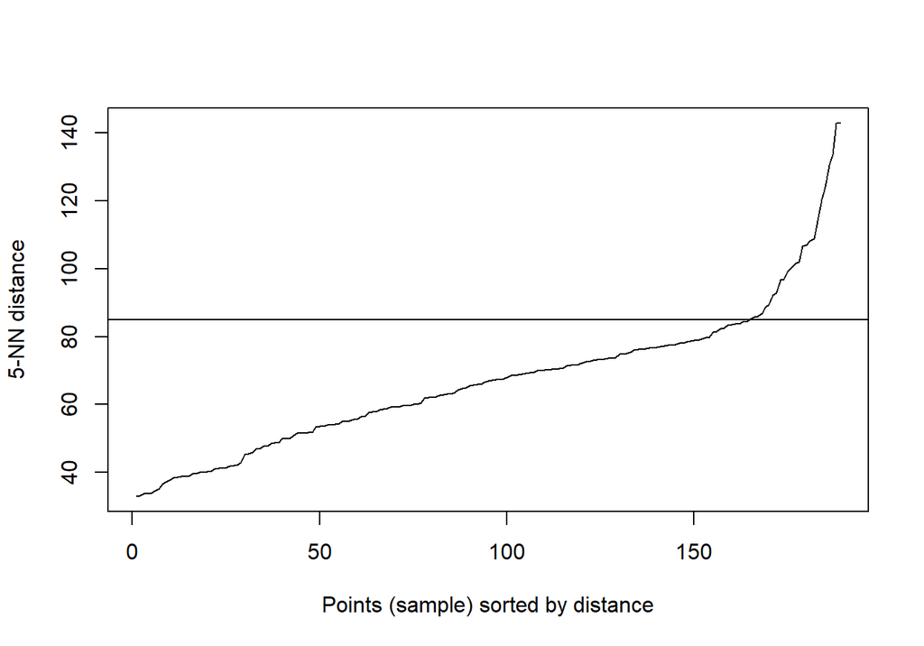

Five-nearest neighbour distances for the gene expression profiling of human tissues data set.

```r
kNNdistplot(t(e), k=5)
abline(h=85)
```

```r
set.seed(42)
res <- dbscan::dbscan(t(e), eps=85, minPts=5)
table(res$cluster)
```

```
##
##  0  1  2  3  4  5  6
## 12 37 62 34 24 15  5
```

```r
table(tissue, res$cluster)
```

```
##
## tissue         0  1  2  3  4  5  6
##   cerebellum   2  0 31  0  0  0  5
##   colon        0  0  0 34  0  0  0
##   endometrium  0  0  0  0  0 15  0
##   hippocampus  0  0 31  0  0  0  0
##   kidney       2 37  0  0  0  0  0
##   liver        2  0  0  0 24  0  0
##   placenta     6  0  0  0  0  0  0
```

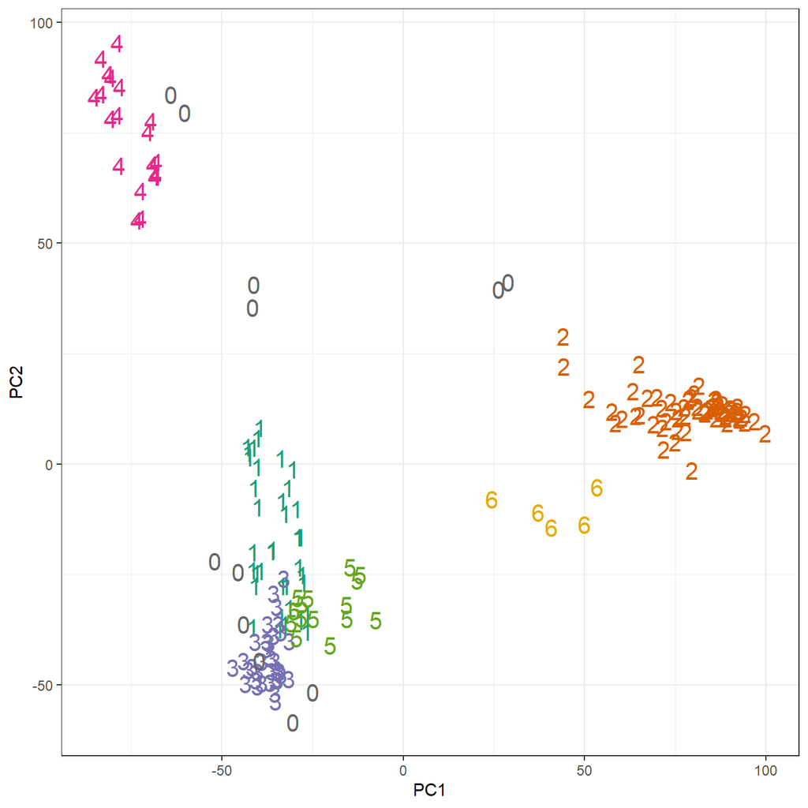

Clustering of human tissue gene expression: scatterplot of first two principal components.

```r
pca <- prcomp(t(e))
ggplot(data=as.data.frame(pca$x), aes(PC1,PC2)) +
  geom_point(col=brewer.pal(8,"Dark2")[c(8,1:7)][res$cluster+1],
             shape=c(48:55)[res$cluster+1], size=5) +
  theme_bw()
```

## Exercises

### Exercise 1

Image segmentation is used to partition digital images into distinct regions containing pixels with similar attributes. Applications include identifying objects or structures in biomedical images. The aim of this exercise is to use k-means clustering to segment the image of a histological section of lung tissue into distinct biological structures, based on pixel colour.

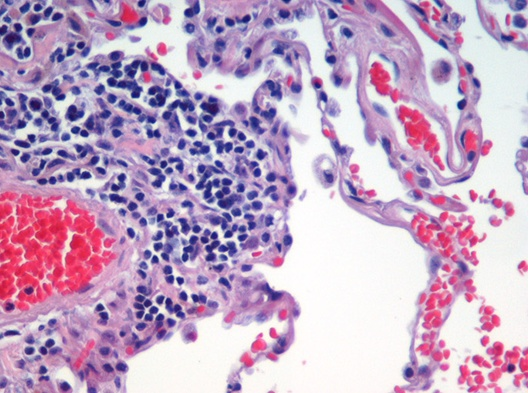

Image of haematoxylin and eosin (H&E) stained section of lung tissue from a patient with end-stage emphysema. CC BY 2.0, https://commons.wikimedia.org/w/index.php?curid=437645.

The haematoxylin and eosin (H & E) staining reveals four types of biological objects, identified by the following colours:

- blue-purple: cell nuclei
- red: red blood cells
- pink: other cell bodies and extracellular material
- white: air spaces

**Consider the following questions:**

- Can k-means clustering find the four biological objects in the image based on pixel colour?
- Earlier we saw that if we plot the total within-cluster sum of squares against k, the position of the “elbow” is a useful guide to choosing the appropriate value of k. According to the “elbow” method, how many distinct clusters (colours) of pixels are present in the image?

**Hints:** If you haven’t worked with images in R before, you may find the following information helpful.

The package [EBImage](https://bioconductor.org/packages/EBImage/) provides a suite of tools for working with images. We will use it to read the file containing the image of the lung section.

```r
library(EBImage)
library(methods)
img <- readImage("data/histology/Emphysema_H_and_E.jpg")
```

`img` is an object of the [EBImage](https://bioconductor.org/packages/EBImage/) class Image; it is essentially a multidimensional array containing the pixel intensities. To see the dimensions of the array, run:

```r
dim(img)
```

```
## [1] 528 393   3
```

In the case of this colour image, the array is 3-dimensional with 528 x 393 x 3 elements. These dimensions correspond to the image width (in pixels), image height and number of colour channels, respectively. The colour channels are red, green and blue (RGB).

Before we can cluster the pixels on colour, we need to convert the 3D array into a 2D data.frame (or matrix). Specifically, we require a data.frame (or matrix) where rows represent pixels and there is a column for the intensity of each of the three colour channels. We also need columns for the x and y coordinates of each pixel.

```r
imgDim <- dim(img)
imgDF <- data.frame(
  x = rep(1:imgDim[1], imgDim[2]),
  y = rep(imgDim[2]:1, each=imgDim[1]),
  r = as.vector(img[,,1]),
  g = as.vector(img[,,2]),
  b = as.vector(img[,,3])
)
```

If the data in `imgDF` are correct, we should be able to display the image using ggplot:

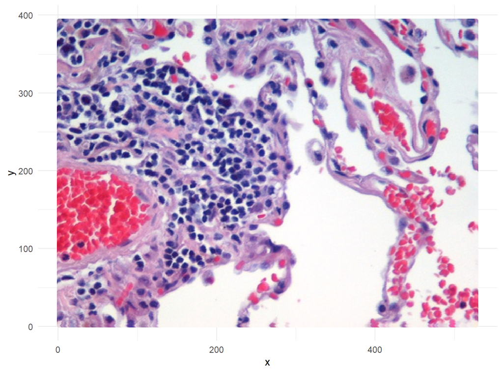

Image of lung tissue recreated from reshaped data.

```r
ggplot(data = imgDF, aes(x = x, y = y)) +
  geom_point(colour = rgb(imgDF[c("r", "g", "b")])) +
  xlab("x") +
  ylab("y") +
  theme_minimal()
```

This should be all the information you need to perform this exercise.

**Solutions to exercises can be found in E2_Clustering_ExerciseSolutions.**